# Analysis of data from HFD mice on dexamethasone

Laura Gunder and Dave Bridges

January 10th, 2019

# 1 Purpose

# 2 Experimental Details

# 3 Raw Data

# 4 Analysis

We removed mouse 6013 double-checked nerve when done with muscle and 7179 slipped at 100hz for muscle stim, could not get higher force after that

# 5 Number of Measurements

Number of animals at sacrifice

[output not shown]

Generated summary data for each measurement

## 5.1 Body Weight

[figure not shown]

| term | df | sumsq | meansq | statistic | p.value |
| --- | --- | --- | --- | --- | --- |
| Diet | 1 | 580659881 | 580659881 | 53.4 | 0.000 |
| Treatment | 1 | 273204903 | 273204903 | 25.1 | 0.000 |
| Diet:Treatment | 1 | 157152286 | 157152286 | 14.5 | 0.001 |
| Residuals | 22 | 239054083 | 10866095 | NA | NA |

| Sex | Diet | Treatment | Measurement | mean.n | se |
| --- | --- | --- | --- | --- | --- |
| Male | NCD | Water | Weight | 31500 | 754 |
| Male | NCD | Dexamethasone | Weight | 29212 | 1450 |
| Male | HFD | Water | Weight | 46540 | 980 |
| Male | HFD | Dexamethasone | Weight | 34267 | 1615 |

## 5.2 Lean Mass

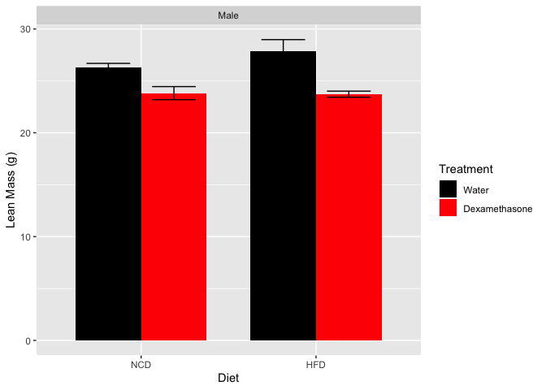

ANOVA of Lean Mass

| term | df | sumsq | meansq | statistic | p.value |
| --- | --- | --- | --- | --- | --- |
| Diet | 1 | 1896602 | 1896602 | 0.751 | 0.396 |
| Treatment | 1 | 56506365 | 56506365 | 22.386 | 0.000 |
| Diet:Treatment | 1 | 3813911 | 3813911 | 1.511 | 0.233 |
| Residuals | 20 | 50482818 | 2524141 | NA | NA |

Summary data for lean mass

| Sex | Diet | Treatment | Measurement | mean.n | se |
| --- | --- | --- | --- | --- | --- |
| Male | NCD | Water | Lean.Mass | 26283 | 404 |
| Male | NCD | Dexamethasone | Lean.Mass | 23820 | 629 |
| Male | HFD | Water | Lean.Mass | 27838 | 1137 |
| Male | HFD | Dexamethasone | Lean.Mass | 23720 | 292 |

## 5.3 Fat Mass

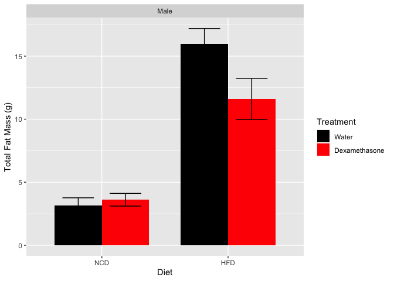

ANOVA of Fat Mass

| term | df | sumsq | meansq | statistic | p.value |
| --- | --- | --- | --- | --- | --- |
| Diet | 1 | 658630691 | 658630691 | 103.93 | 0.000 |
| Treatment | 1 | 16030350 | 16030350 | 2.53 | 0.126 |
| Diet:Treatment | 1 | 36522274 | 36522274 | 5.76 | 0.025 |
| Residuals | 22 | 139419089 | 6337231 | NA | NA |

Summary data for fat mass

| Sex | Diet | Treatment | Measurement | mean.n | se |
| --- | --- | --- | --- | --- | --- |
| Male | NCD | Water | Fat.Mass | 3154 | 610 |
| Male | NCD | Dexamethasone | Fat.Mass | 3611 | 504 |
| Male | HFD | Water | Fat.Mass | 15962 | 1226 |
| Male | HFD | Dexamethasone | Fat.Mass | 11605 | 1628 |

Summary data for percent fat mass

| Sex | Diet | Treatment | Measurement | mean.n | se |
| --- | --- | --- | --- | --- | --- |
| Male | NCD | Water | Pct.Fat.Mass | 9.85 | 1.72 |
| Male | NCD | Dexamethasone | Pct.Fat.Mass | 12.11 | 1.24 |
| Male | HFD | Water | Pct.Fat.Mass | 34.16 | 1.97 |
| Male | HFD | Dexamethasone | Pct.Fat.Mass | 33.27 | 3.22 |

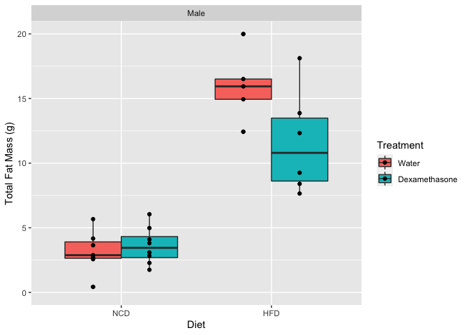

## 5.4 Blood Glucose

significant for FBG diet is conditional on treatment, significant interaction between diet and treatment It tests whether the average treatment effect is the different for each diet, the respective diets. effect of the treatment (difference between treated and control) differs between NCD and HFD

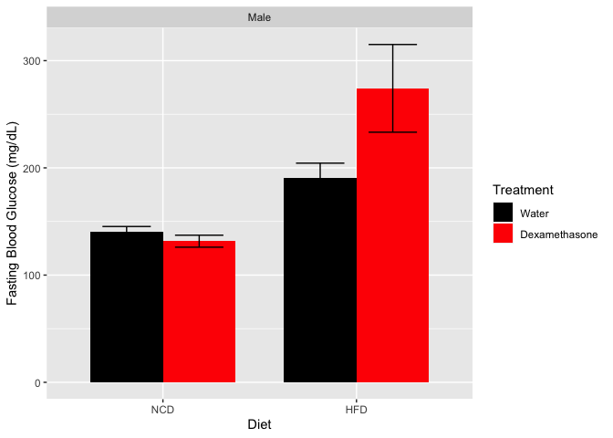

ANOVA of FBG

| term | df | sumsq | meansq | statistic | p.value |
| --- | --- | --- | --- | --- | --- |
| Diet | 1 | 64349 | 64349 | 25.02 | 0.000 |
| Treatment | 1 | 5855 | 5855 | 2.28 | 0.146 |
| Diet:Treatment | 1 | 13289 | 13289 | 5.17 | 0.033 |
| Residuals | 22 | 56572 | 2571 | NA | NA |

## 5.5 Gastrocnemius Weight

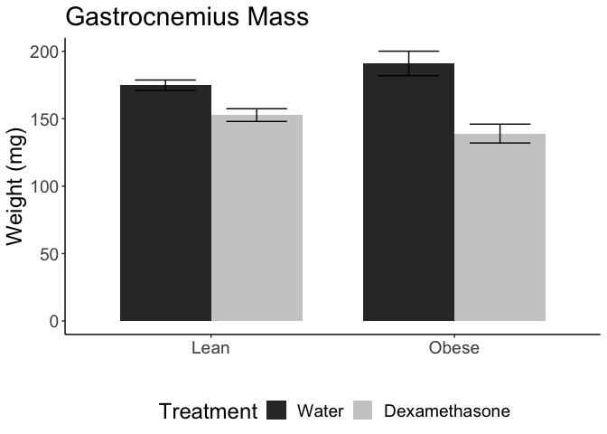

ANOVA of Gastroc Weights

| term | df | sumsq | meansq | statistic | p.value |
| --- | --- | --- | --- | --- | --- |
| Diet | 1 | 1.03 | 1.03 | 0.005 | 0.947 |
| Treatment | 1 | 7796.87 | 7796.87 | 34.308 | 0.000 |
| Diet:Treatment | 1 | 1406.09 | 1406.09 | 6.187 | 0.021 |
| Residuals | 22 | 4999.81 | 227.26 | NA | NA |

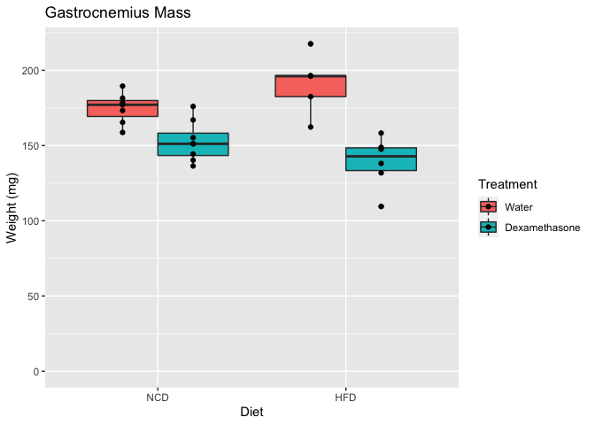

ANOVA of Gastroc Weights

| term | df | sumsq | meansq | statistic | p.value |
| --- | --- | --- | --- | --- | --- |
| Diet | 1 | 1.03 | 1.03 | 0.005 | 0.947 |
| Treatment | 1 | 7796.87 | 7796.87 | 34.308 | 0.000 |
| Diet:Treatment | 1 | 1406.09 | 1406.09 | 6.187 | 0.021 |
| Residuals | 22 | 4999.81 | 227.26 | NA | NA |

### 5.5.1 Relative Gastroc Weight

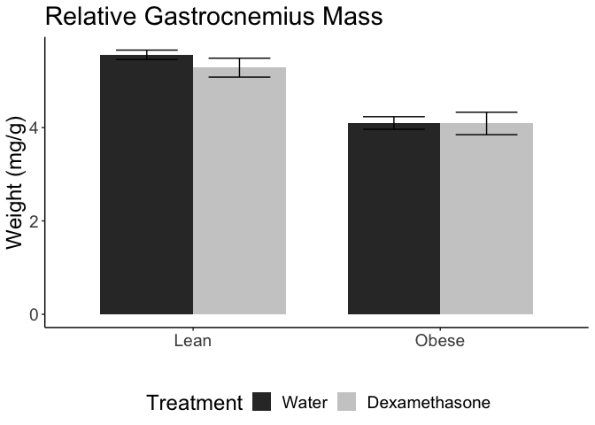

ANOVA of Relative Gastroc Weights

| term | df | sumsq | meansq | statistic | p.value |
| --- | --- | --- | --- | --- | --- |
| Diet | 1 | 11.035 | 11.035 | 50.351 | 0.000 |
| Treatment | 1 | 0.171 | 0.171 | 0.781 | 0.386 |
| Diet:Treatment | 1 | 0.110 | 0.110 | 0.503 | 0.486 |
| Residuals | 22 | 4.822 | 0.219 | NA | NA |

ANOVA of Relative Gastroc Weights with no interaction

| term | df | sumsq | meansq | statistic | p.value |
| --- | --- | --- | --- | --- | --- |
| Diet | 1 | 11.035 | 11.035 | 51.464 | 0.000 |
| Treatment | 1 | 0.171 | 0.171 | 0.799 | 0.381 |
| Residuals | 23 | 4.932 | 0.214 | NA | NA |

The gastroc weights are reduced **12.657%** in the NCD animals and **27.225%** in the HFD animals.

## 5.6 Cross-Sectional Area

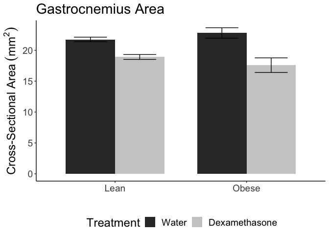

ANOVA of CSA

| term | df | sumsq | meansq | statistic | p.value |
| --- | --- | --- | --- | --- | --- |
| Diet | 1 | 0.50 | 0.50 | 0.156 | 0.697 |
| Treatment | 1 | 95.64 | 95.64 | 29.805 | 0.000 |
| Diet:Treatment | 1 | 8.92 | 8.92 | 2.781 | 0.110 |
| Residuals | 22 | 70.59 | 3.21 | NA | NA |

The whole muscle cross-sectional areas are reduced **13.069%** in the NCD animals and **22.9%** in the HFD animals.

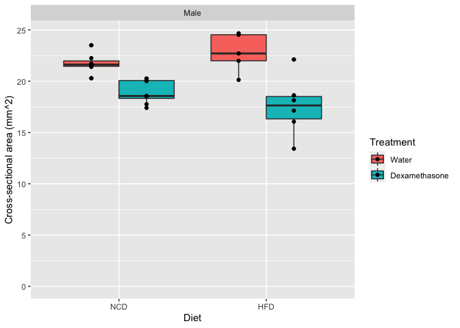

ANOVA of CSA

| term | df | sumsq | meansq | statistic | p.value |
| --- | --- | --- | --- | --- | --- |
| Diet | 1 | 0.50 | 0.50 | 0.156 | 0.697 |
| Treatment | 1 | 95.64 | 95.64 | 29.805 | 0.000 |
| Diet:Treatment | 1 | 8.92 | 8.92 | 2.781 | 0.110 |
| Residuals | 22 | 70.59 | 3.21 | NA | NA |

## 5.7 Force

### 5.7.1 Force - Muscle

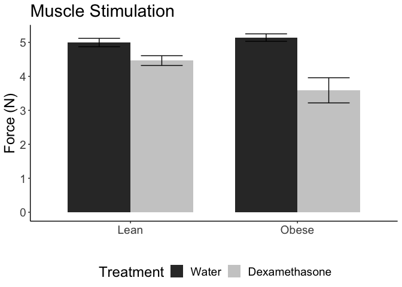

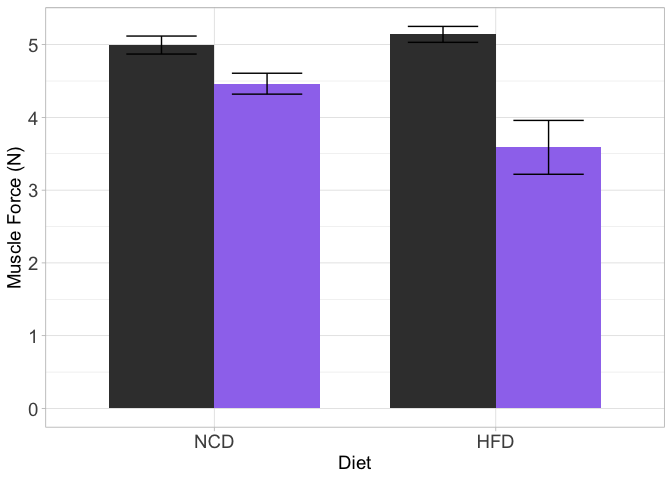

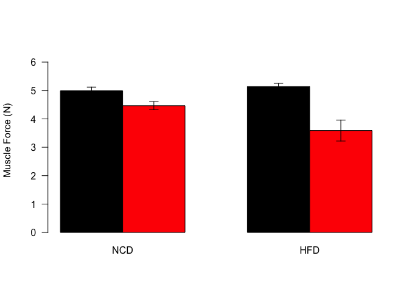

ANOVA of Muscle force measurements

| term | df | sumsq | meansq | statistic | p.value |
| --- | --- | --- | --- | --- | --- |
| Diet | 1 | 1.10 | 1.103 | 3.95 | 0.059 |
| Treatment | 1 | 5.98 | 5.983 | 21.41 | 0.000 |
| Diet:Treatment | 1 | 1.65 | 1.645 | 5.89 | 0.024 |
| Residuals | 22 | 6.15 | 0.279 | NA | NA |

Summary statistics for muscle stimulation

| Treatment | Diet | Mean | SE | SD | n | shapiro | Rel.SD |
| --- | --- | --- | --- | --- | --- | --- | --- |
| Water | NCD | 4.99 | 0.124 | 0.327 | 7 | 0.529 | 6.55 |
| Water | HFD | 5.14 | 0.109 | 0.245 | 5 | 0.532 | 4.76 |
| Dexamethasone | NCD | 4.46 | 0.144 | 0.406 | 8 | 0.104 | 9.10 |
| Dexamethasone | HFD | 3.59 | 0.370 | 0.907 | 6 | 0.987 | 25.26 |

Levene’s tests for NCD and HFD respectively

| term | df | statistic | p.value |
| --- | --- | --- | --- |
| group | 1 | 0.172 | 0.685 |
|  | 13 | NA | NA |
| group | 1 | 4.012 | 0.076 |
|  | 9 | NA | NA |

Pairwise significance testing for effects of dexamethasone on muscle-stimulated contraction

| Diet | Student | Welch |
| --- | --- | --- |
| NCD | 0.016 | 0.015 |
| HFD | 0.005 | 0.007 |

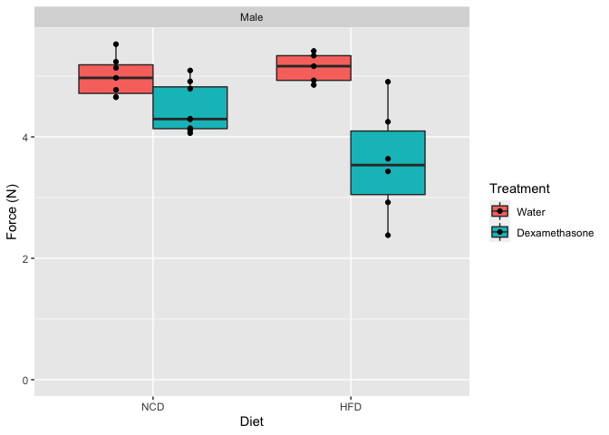

ANOVA of Muscle force measurements

| term | df | sumsq | meansq | statistic | p.value |
| --- | --- | --- | --- | --- | --- |
| Diet | 1 | 1.10 | 1.103 | 3.95 | 0.059 |
| Treatment | 1 | 5.98 | 5.983 | 21.41 | 0.000 |
| Diet:Treatment | 1 | 1.65 | 1.645 | 5.89 | 0.024 |
| Residuals | 22 | 6.15 | 0.279 | NA | NA |

### 5.7.2 Force - Nerve

significant for force generated by nerve stimulation diet is conditional on treatment, significant interaction between diet and treatment It tests whether the average treatment effect is the different for each diet, the respective diets. effect of the treatment (difference between treated and control) differs between NCD and HFD

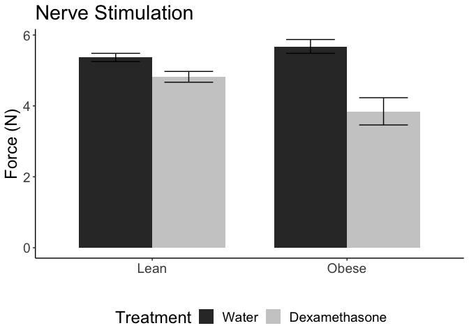

Summary statistics for nerve stimulation

| Treatment | Diet | Mean | SE | SD | n | shapiro | Rel.SD |
| --- | --- | --- | --- | --- | --- | --- | --- |
| Water | NCD | 5.37 | 0.116 | 0.307 | 7 | 0.644 | 5.72 |
| Water | HFD | 5.68 | 0.195 | 0.436 | 5 | 0.706 | 7.69 |
| Dexamethasone | NCD | 4.82 | 0.153 | 0.431 | 8 | 0.514 | 8.95 |
| Dexamethasone | HFD | 3.85 | 0.384 | 0.941 | 6 | 0.894 | 24.45 |

Levene’s tests for NCD and HFD respectively for nerve stimulation

| term | df | statistic | p.value |
| --- | --- | --- | --- |
| group | 1 | 1.09 | 0.315 |
|  | 13 | NA | NA |
| group | 1 | 1.74 | 0.220 |
|  | 9 | NA | NA |

Pairwise significance testing for effects of dexamethasone on nerve-stimulated contraction

| Diet | Student | Welch |
| --- | --- | --- |
| NCD | 0.015 | 0.014 |
| HFD | 0.003 | 0.003 |

ANOVA of Nerve force measurements

| term | df | sumsq | meansq | statistic | p.value |
| --- | --- | --- | --- | --- | --- |
| Diet | 1 | 0.996 | 0.996 | 3.10 | 0.092 |
| Treatment | 1 | 7.657 | 7.657 | 23.87 | 0.000 |
| Diet:Treatment | 1 | 2.600 | 2.600 | 8.11 | 0.009 |
| Residuals | 22 | 7.056 | 0.321 | NA | NA |

[figure not shown]

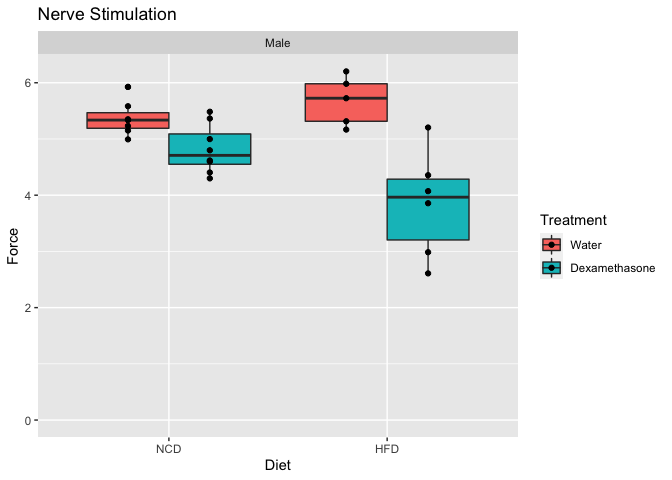

ANOVA of Nerve force measurements

| term | df | sumsq | meansq | statistic | p.value |
| --- | --- | --- | --- | --- | --- |
| Diet | 1 | 0.996 | 0.996 | 3.10 | 0.092 |
| Treatment | 1 | 7.657 | 7.657 | 23.87 | 0.000 |
| Diet:Treatment | 1 | 2.600 | 2.600 | 8.11 | 0.009 |
| Residuals | 22 | 7.056 | 0.321 | NA | NA |

## 5.8 Overall Reductions in NCD/HFD

Absolute and Relative Decreases with Dexamethasone

| Sex | Diet | Measure | Water | Dexamethasone | Reduction | Percent.Reduction |
| --- | --- | --- | --- | --- | --- | --- |
| Male | NCD | CSA_mean.n | 21.75 | 18.91 | 2.843 | 13.069 |
| Male | HFD | CSA_mean.n | 22.81 | 17.58 | 5.223 | 22.900 |
| Male | NCD | Fat.Mass_mean.n | 3154.29 | 3611.25 | -456.964 | -14.487 |
| Male | HFD | Fat.Mass_mean.n | 15962.00 | 11605.00 | 4357.000 | 27.296 |
| Male | NCD | FBG_mean.n | 140.29 | 131.62 | 8.661 | 6.174 |
| Male | HFD | FBG_mean.n | 191.00 | 274.17 | -83.167 | -43.543 |
| Male | NCD | Gastroc_mean.n | 174.84 | 152.71 | 22.130 | 12.657 |
| Male | HFD | Gastroc_mean.n | 191.00 | 139.00 | 52.000 | 27.225 |
| Male | NCD | Gastroc.rel_mean.n | 5.56 | 5.28 | 0.274 | 4.939 |
| Male | HFD | Gastroc.rel_mean.n | 4.10 | 4.09 | 0.010 | 0.244 |
| Male | NCD | Lean.Mass_mean.n | 26282.86 | 23820.00 | 2462.857 | 9.371 |
| Male | HFD | Lean.Mass_mean.n | 27837.50 | 23720.00 | 4117.500 | 14.791 |
| Male | NCD | Pct.Fat.Mass_mean.n | 9.85 | 12.11 | -2.266 | -23.007 |
| Male | HFD | Pct.Fat.Mass_mean.n | 34.16 | 33.27 | 0.887 | 2.598 |
| Male | NCD | Po-Muscle (mN)_mean.n | 4994.29 | 4463.25 | 531.036 | 10.633 |
| Male | HFD | Po-Muscle (mN)_mean.n | 5141.00 | 3588.33 | 1552.667 | 30.202 |
| Male | NCD | Po-Muscle (N)_mean.n | 4.99 | 4.46 | 0.531 | 10.633 |
| Male | HFD | Po-Muscle (N)_mean.n | 5.14 | 3.59 | 1.553 | 30.202 |
| Male | NCD | Po-Nerve (mN)_mean.n | 5367.14 | 4820.62 | 546.518 | 10.183 |
| Male | HFD | Po-Nerve (mN)_mean.n | 5678.20 | 3847.33 | 1830.867 | 32.244 |
| Male | NCD | Po-Nerve (N)_mean.n | 5.37 | 4.82 | 0.547 | 10.183 |
| Male | HFD | Po-Nerve (N)_mean.n | 5.68 | 3.85 | 1.831 | 32.244 |
| Male | NCD | Spo Muscle (N/cm2)_mean.n | 22.97 | 23.60 | -0.627 | -2.729 |
| Male | HFD | Spo Muscle (N/cm2)_mean.n | 22.63 | 20.47 | 2.161 | 9.546 |
| Male | NCD | Spo Nerve (N/cm2)_mean.n | 24.69 | 25.50 | -0.813 | -3.292 |
| Male | HFD | Spo Nerve (N/cm2)_mean.n | 24.97 | 21.89 | 3.082 | 12.342 |
| Male | NCD | Weight_mean.n | 31500.00 | 29212.50 | 2287.500 | 7.262 |
| Male | HFD | Weight_mean.n | 46540.00 | 34266.67 | 12273.333 | 26.372 |

### 5.8.1 Force versus CSA

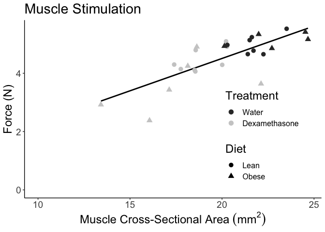

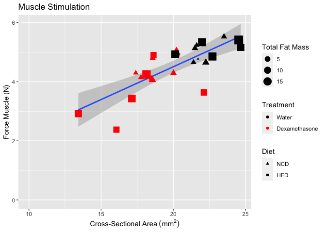

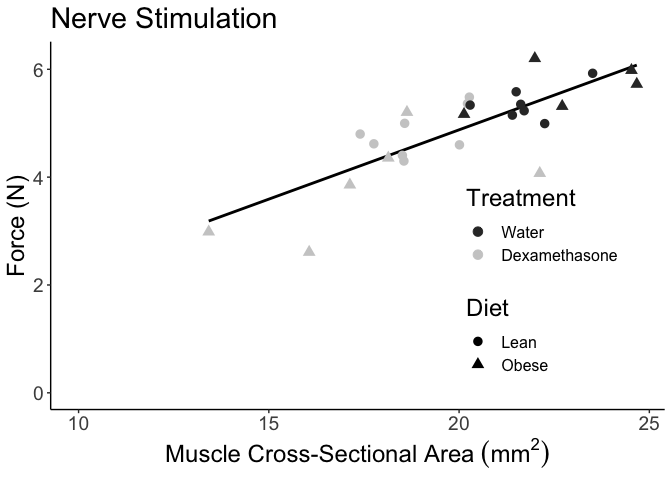

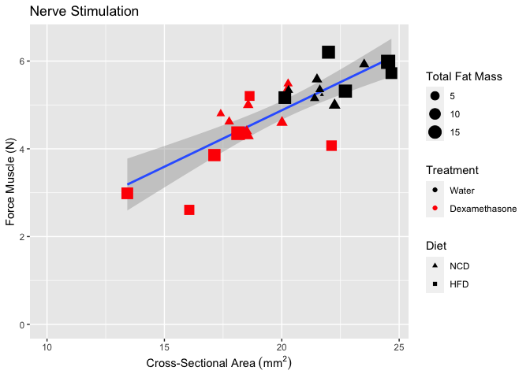

Linear model regressing against cross-sectional area

| term | estimate | std.error | statistic | p.value |
| --- | --- | --- | --- | --- |
| (Intercept) | 0.068 | 0.779 | 0.087 | 0.931 |
| CSA | 0.222 | 0.038 | 5.781 | 0.000 |

Linear model regressing against cross-sectional area, showing fit

| r.squared | adj.r.squared | sigma | statistic | p.value | df | logLik | AIC | BIC | deviance | df.residual | nobs |
| --- | --- | --- | --- | --- | --- | --- | --- | --- | --- | --- | --- |
| 0.582 | 0.565 | 0.509 | 33.4 | 0 | 1 | -18.3 | 42.6 | 46.4 | 6.22 | 24 | 26 |

Linear model including dexamethasone treatment as a covariate

| term | estimate | std.error | statistic | p.value |
| --- | --- | --- | --- | --- |
| (Intercept) | 0.904 | 1.281 | 0.706 | 0.487 |
| CSA | 0.187 | 0.057 | 3.262 | 0.003 |
| TreatmentDexamethasone | -0.247 | 0.299 | -0.826 | 0.417 |

Linear model including dexamethasone treatment as a covariate, showing fit

| r.squared | adj.r.squared | sigma | statistic | p.value | df | logLik | AIC | BIC | deviance | df.residual | nobs |
| --- | --- | --- | --- | --- | --- | --- | --- | --- | --- | --- | --- |
| 0.594 | 0.559 | 0.512 | 16.8 | 0 | 2 | -17.9 | 43.8 | 48.9 | 6.04 | 23 | 26 |

# 6 Interpretation

Changes in force are proportional to changes in CSA. CSA is the determining factor in strength as measured by force generated through stimulation of nerve and muscle in gastroc. force versus cross-sectional-understand whether muscle strength will decline in proportion only to the size. reitterated- look at SPo or specific force If muscle strength is reduced primary due to neuropathy, perhaps secondary to diabetes in these mice, we will identify this by comparing neuronal to direct muscle stimulation

# 8 References